# Prediction_Project

LaKeya King

2026-05-24

## Background

Using wearable devices such as Jawbone Up, Nike FuelBand, and Fitbit, it is possible to collect detailed information about physical activity. In this project, accelerometer data collected from the belt, forearm, arm, and dumbbell of six participants were used to predict the manner in which participants performed barbell lifts.

The outcome variable is **classe**, which indicates whether the exercise was performed correctly or incorrectly.

## Load Data

```r
training <- read.csv("pml-training.csv", na.strings=c("NA","#DIV/0!",""))
testing  <- read.csv("pml-testing.csv", na.strings=c("NA","#DIV/0!",""))

dim(training)
```

```
## [1] 19622   160
```

```r
dim(testing)
```

```
## [1]  20 160
```

## Data Cleaning

First, remove variables with mostly missing values.

```r
naCols <- colSums(is.na(training)) > 0.95*nrow(training)
training <- training[, !naCols]
testing  <- testing[, !naCols]
```

Remove non-predictive variables (ID/time variables).

```r
training <- training[, -(1:7)]
testing  <- testing[, -(1:7)]

dim(training)
```

```
## [1] 19622    53
```

```r
dim(testing)
```

```
## [1] 20 53
```

# Partition Data

Use 70% for training and 30% for validation.

```r
inTrain <- createDataPartition(training$classe, p = 0.7, list = FALSE)

trainSet <- training[inTrain, ]
validSet <- training[-inTrain, ]

dim(trainSet)
```

```
## [1] 13737    53
```

```r
dim(validSet)
```

```
## [1] 5885   53
```

## Cross Validation Setup

Use 5-fold cross-validation.

```r
control <- trainControl(
  method = "cv",
  number = 5
)
```

## Model 1: Decision Tree

```r
model_tree <- train(
  classe ~ .,
  data = trainSet,
  method = "rpart",
  trControl = control
)

model_tree
```

```
## CART
##
## 13737 samples
##    52 predictor
##     5 classes: 'A', 'B', 'C', 'D', 'E'
##
## No pre-processing
## Resampling: Cross-Validated (5 fold)
## Summary of sample sizes: 10987, 10990, 10990, 10991, 10990
## Resampling results across tuning parameters:
##
##   cp          Accuracy   Kappa
##   0.03458448  0.5269759  0.39101780
##   0.06092971  0.3911382  0.16699598
##   0.11595972  0.3326679  0.07359069
##
## Accuracy was used to select the optimal model using the largest value.
## The final value used for the model was cp = 0.03458448.
```

Plot tree:

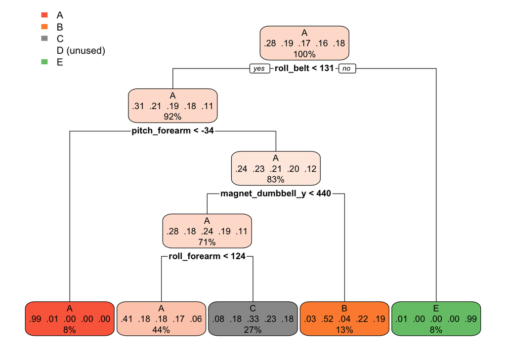

```r
rpart.plot(model_tree$finalModel)
```

## Model 2: Random Forest

```r
model_rf <- train(
  classe ~ .,
  data = trainSet,
  method = "rf",
  trControl = control,
  ntree = 250
)

model_rf
```

```
## Random Forest
##
## 13737 samples
##    52 predictor
##     5 classes: 'A', 'B', 'C', 'D', 'E'
##
## No pre-processing
## Resampling: Cross-Validated (5 fold)
## Summary of sample sizes: 10990, 10989, 10990, 10990, 10989
## Resampling results across tuning parameters:
##
##   mtry  Accuracy   Kappa
##    2    0.9896630  0.9869232
##   27    0.9898085  0.9871072
##   52    0.9834027  0.9790027
##
## Accuracy was used to select the optimal model using the largest value.
## The final value used for the model was mtry = 27.
```

# Decision Tree

```r
pred_tree <- predict(model_tree, newdata = validSet)

pred_tree <- factor(pred_tree,
                    levels = c("A","B","C","D","E"))

actual_tree <- factor(validSet$classe,
                      levels = c("A","B","C","D","E"))

cm_tree <- confusionMatrix(
  data = pred_tree,
  reference = actual_tree
)

cm_tree
```

```
## Confusion Matrix and Statistics
##
##           Reference
## Prediction    A    B    C    D    E
##          A 1525  484  499  423  153
##          B   29  385   37  187  159
##          C  116  270  490  354  289
##          D    0    0    0    0    0
##          E    4    0    0    0  481
##
## Overall Statistics
##
##                Accuracy : 0.4895
##                  95% CI : (0.4767, 0.5024)
##     No Information Rate : 0.2845
##     P-Value [Acc > NIR] : < 2.2e-16
##
##                   Kappa : 0.3324
##
##  Mcnemar's Test P-Value : NA
##
## Statistics by Class:
##
##                      Class: A Class: B Class: C Class: D Class: E
## Sensitivity            0.9110  0.33802  0.47758   0.0000  0.44455
## Specificity            0.6298  0.91319  0.78823   1.0000  0.99917
## Pos Pred Value         0.4945  0.48306  0.32258      NaN  0.99175
## Neg Pred Value         0.9468  0.85181  0.87723   0.8362  0.88870
## Prevalence             0.2845  0.19354  0.17434   0.1638  0.18386
## Detection Rate         0.2591  0.06542  0.08326   0.0000  0.08173
## Detection Prevalence   0.5240  0.13543  0.25811   0.0000  0.08241
## Balanced Accuracy      0.7704  0.62560  0.63291   0.5000  0.72186
```

```r
## Random Forest
pred_rf <- predict(model_rf, newdata = validSet)

pred_rf <- factor(pred_rf,
                  levels = c("A","B","C","D","E"))

actual_rf <- factor(validSet$classe,
                    levels = c("A","B","C","D","E"))

cm_rf <- confusionMatrix(
  data = pred_rf,
  reference = actual_rf
)

cm_rf
```

```
## Confusion Matrix and Statistics
##
##           Reference
## Prediction    A    B    C    D    E
##          A 1673    8    0    0    0
##          B    1 1128    7    0    0
##          C    0    3 1017    7    1
##          D    0    0    2  957    2
##          E    0    0    0    0 1079
##
## Overall Statistics
##
##                Accuracy : 0.9947
##                  95% CI : (0.9925, 0.9964)
##     No Information Rate : 0.2845
##     P-Value [Acc > NIR] : < 2.2e-16
##
##                   Kappa : 0.9933
##
##  Mcnemar's Test P-Value : NA
##
## Statistics by Class:
##
##                      Class: A Class: B Class: C Class: D Class: E
## Sensitivity            0.9994   0.9903   0.9912   0.9927   0.9972
## Specificity            0.9981   0.9983   0.9977   0.9992   1.0000
## Pos Pred Value         0.9952   0.9930   0.9893   0.9958   1.0000
## Neg Pred Value         0.9998   0.9977   0.9981   0.9986   0.9994
## Prevalence             0.2845   0.1935   0.1743   0.1638   0.1839
## Detection Rate         0.2843   0.1917   0.1728   0.1626   0.1833
## Detection Prevalence   0.2856   0.1930   0.1747   0.1633   0.1833
## Balanced Accuracy      0.9988   0.9943   0.9945   0.9960   0.9986
```

## Selected Model

The Random Forest model produced substantially higher accuracy and lower out-of-sample error than the Decision Tree model, so it was selected as the final model.

Expected out-of-sample error:

```r
1 - cm_rf$overall["Accuracy"]
```

```
##   Accuracy
## 0.00526763
```

This error rate is expected to be approximately **< 1%**.

## Final Prediction on Test Data

```r
final_predictions <- predict(model_rf, testing)
final_predictions
```

```
##  [1] B A B A A E D B A A B C B A E E A B B B
## Levels: A B C D E
```

## Conclusion

The Random Forest algorithm was selected because it produced the highest validation accuracy. Cross-validation was used to reduce overfitting and estimate future performance. The final model achieved approximately **99% accuracy**, suggesting excellent predictive performance for identifying exercise quality.

## Appendix

Variable Importance

```r
varImp(model_rf)
```

```
## rf variable importance
##
##   only 20 most important variables shown (out of 52)
##
##                      Overall
## roll_belt            100.000
## pitch_forearm         61.064
## yaw_belt              54.473
## pitch_belt            45.320
## magnet_dumbbell_y     45.064
## roll_forearm          43.743
## magnet_dumbbell_z     41.651
## accel_dumbbell_y      22.468
## accel_forearm_x       18.343
## magnet_dumbbell_x     17.202
## accel_belt_z          15.928
## magnet_belt_z         15.693
## roll_dumbbell         14.888
## magnet_forearm_z      14.135
## accel_dumbbell_z      13.481
## total_accel_dumbbell  12.298
## magnet_belt_y         12.108
## gyros_belt_z          11.026
## yaw_arm               10.122
## magnet_belt_x          9.724
```

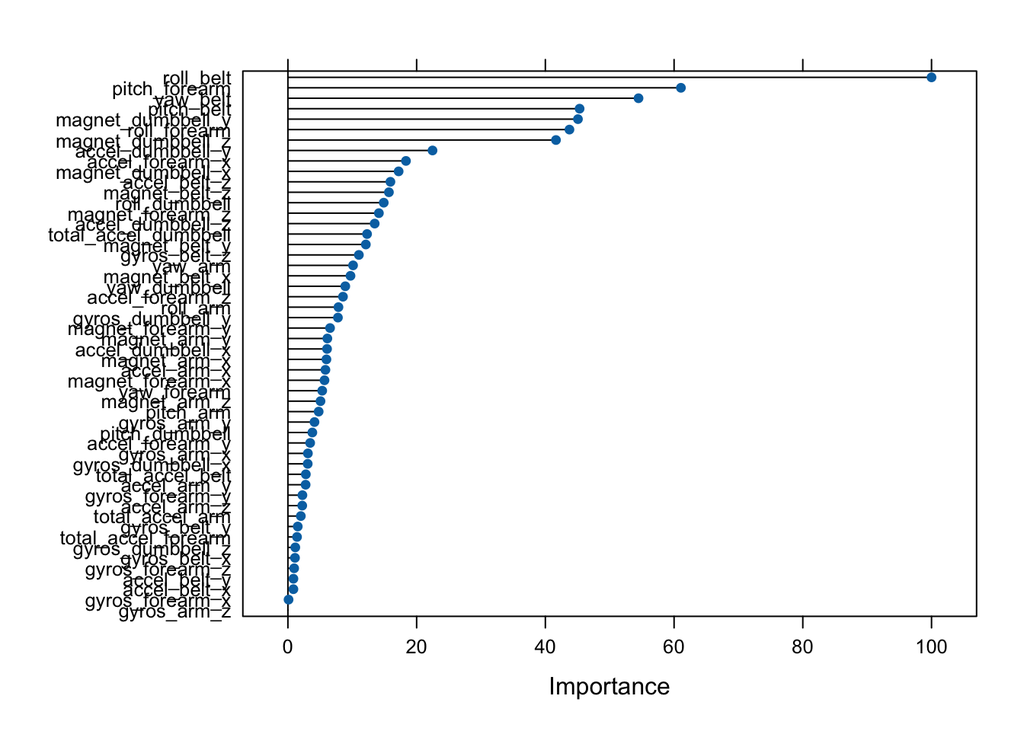

```r
plot(varImp(model_rf))
```